# An Introduction to Statistical Learning

##### **mpg horsepower**

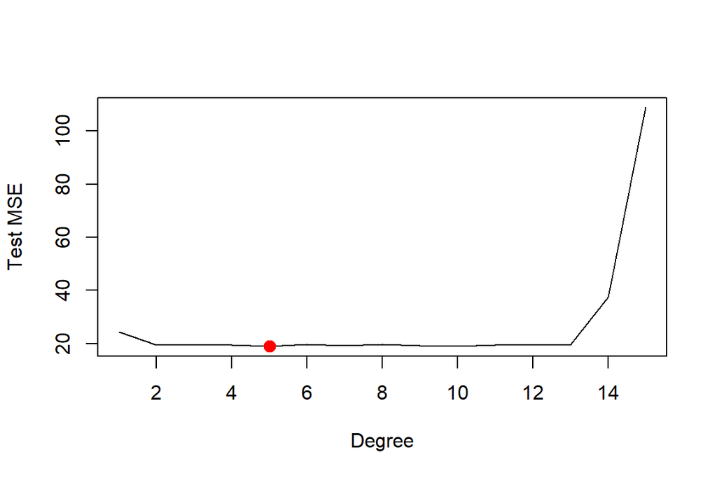

```r
deltas = rep(NA, 15)
for (i in 1:15) {
    fit = glm(mpg ~ poly(horsepower, i), data = Auto)
    deltas[i] = cv.glm(Auto, fit, K = 10)$delta[1]
}
plot(1:15, deltas, xlab = "Degree", ylab = "Test MSE", type = "l")
d.min = which.min(deltas)
points(which.min(deltas), deltas[which.min(deltas)], col = "red", cex = 2, pch = 20)
```

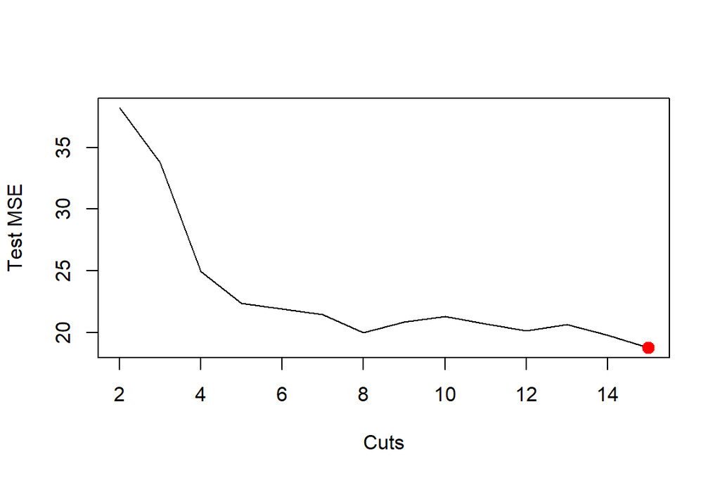

```r
cvs = rep(NA, 15)
for (i in 2:15) {
    Auto$dis.cut = cut(Auto$horsepower, i)
    fit = glm(mpg ~ dis.cut, data = Auto)
    cvs[i] = cv.glm(Auto, fit, K = 10)$delta[1]
}
plot(2:15, cvs[-1], xlab = "Cuts", ylab = "Test MSE", type = "l")
d.min = which.min(cvs)
points(which.min(cvs), cvs[which.min(cvs)], col = "red", cex = 2, pch = 20)
```

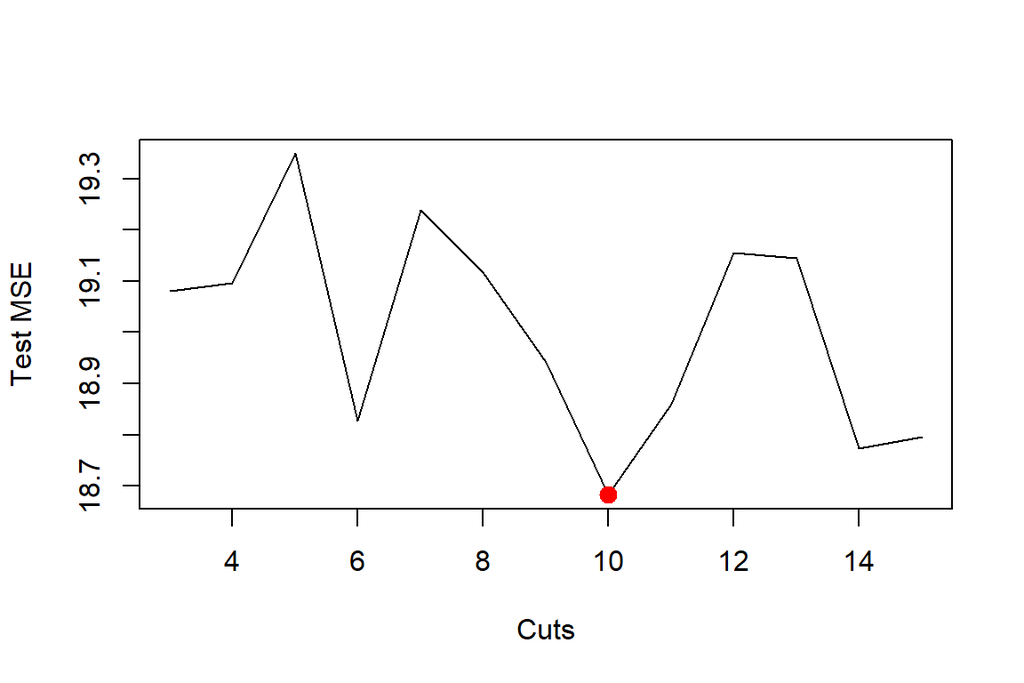

```r
library(splines)
cvs = rep(NA, 15)
for (i in 3:15) {
    fit = glm(mpg ~ ns(horsepower, df = i), data = Auto)
    cvs[i] = cv.glm(Auto, fit, K = 10)$delta[1]
}
plot(3:15, cvs[-c(1, 2)], xlab = "Cuts", ylab = "Test MSE", type = "l")
d.min = which.min(cvs)
points(which.min(cvs), cvs[which.min(cvs)], col = "red", cex = 2, pch = 20)
```

##### **mpg - weight**

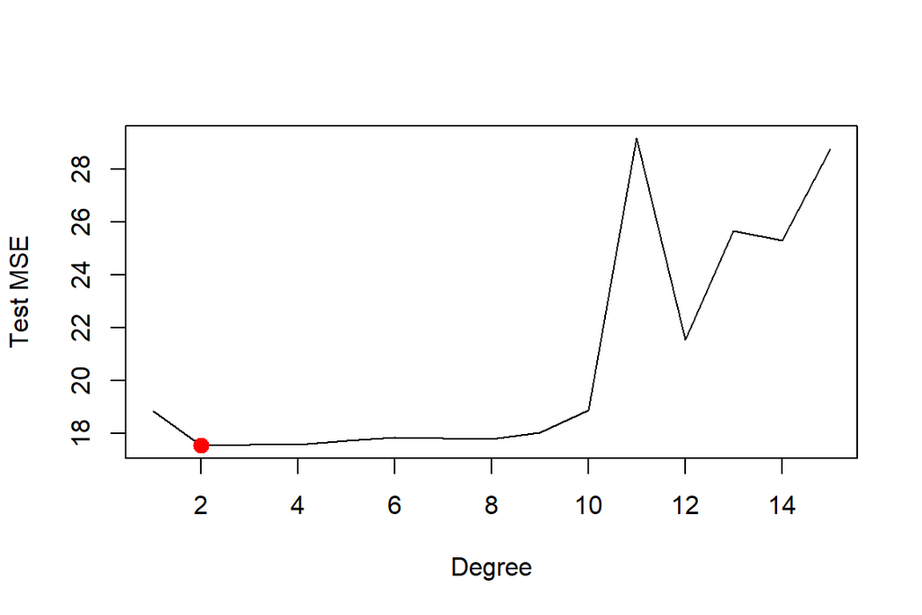

```r
deltas = rep(NA, 15)
for (i in 1:15) {
    fit = glm(mpg ~ poly(weight, i), data = Auto)
    deltas[i] = cv.glm(Auto, fit, K = 10)$delta[1]
}
plot(1:15, deltas, xlab = "Degree", ylab = "Test MSE", type = "l")
d.min = which.min(deltas)
points(which.min(deltas), deltas[which.min(deltas)], col = "red", cex = 2, pch = 20)
```

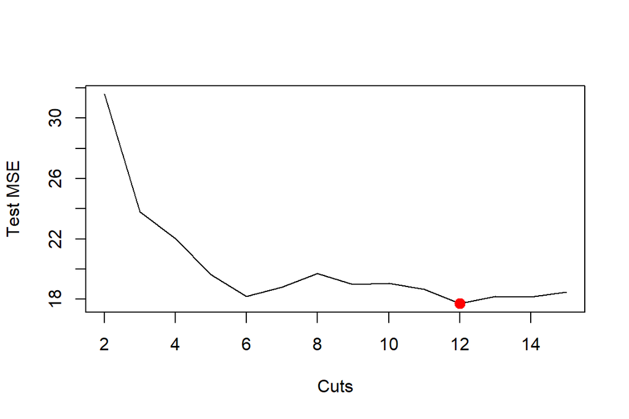

```r
cvs = rep(NA, 15)
for (i in 2:15) {
    Auto$dis.cut = cut(Auto$weight, i)
    fit = glm(mpg ~ dis.cut, data = Auto)
    cvs[i] = cv.glm(Auto, fit, K = 10)$delta[1]
}
plot(2:15, cvs[-1], xlab = "Cuts", ylab = "Test MSE", type = "l")
d.min = which.min(cvs)
points(which.min(cvs), cvs[which.min(cvs)], col = "red", cex = 2, pch = 20)
```

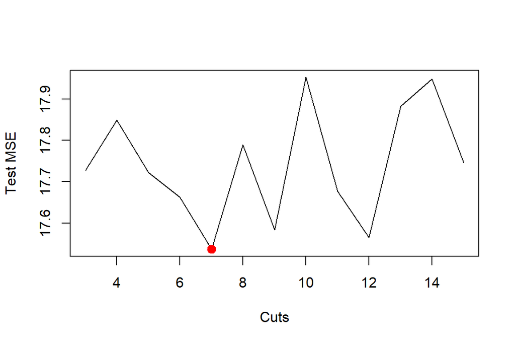

```r
library(splines)
cvs = rep(NA, 15)
for (i in 3:15) {
    fit = glm(mpg ~ ns(weight, df = i), data = Auto)
    cvs[i] = cv.glm(Auto, fit, K = 10)$delta[1]
}
plot(3:15, cvs[-c(1, 2)], xlab = "Cuts", ylab = "Test MSE", type = "l")
d.min = which.min(cvs)
points(which.min(cvs), cvs[which.min(cvs)], col = "red", cex = 2, pch = 20)
```

##### **GAMs**

```r
fit = gam(mpg ~ s(displacement, 11) + s(horsepower, 10)+ s(weight, 7)+ acceleration, data = Auto)
deviance(fit)
```

```
## [1] 5068.748
```

```r
summary(fit)
```

```
##
## Call: gam(formula = mpg ~ s(displacement, 11) + s(horsepower, 10) +
##     s(weight, 7) + acceleration, data = Auto)
## Deviance Residuals:
##     Min      1Q  Median      3Q     Max
## -9.9543 -1.8508 -0.2105  1.7793 16.2185
##
## (Dispersion Parameter for gaussian family taken to be 14.002)
##
##     Null Deviance: 23818.99 on 391 degrees of freedom
## Residual Deviance: 5068.748 on 362.0007 degrees of freedom
## AIC: 2177.805
##
## Number of Local Scoring Iterations: 2
##
## Anova for Parametric Effects
##                      Df  Sum Sq Mean Sq   F value    Pr(>F)
## s(displacement, 11)   1 15063.8 15063.8 1075.8314 < 2.2e-16 ***
## s(horsepower, 10)     1  1140.5  1140.5   81.4535 < 2.2e-16 ***
## s(weight, 7)          1   295.2   295.2   21.0825 6.079e-06 ***
## acceleration          1   111.2   111.2    7.9406  0.005099 **
## Residuals           362  5068.7    14.0
## ---
## Signif. codes:  0 '***' 0.001 '**' 0.01 '*' 0.05 '.' 0.1 ' ' 1
##
## Anova for Nonparametric Effects
##                     Npar Df Npar F     Pr(F)
## (Intercept)
## s(displacement, 11)      10 3.6826 0.0001044 ***
## s(horsepower, 10)         9 6.8397 4.253e-09 ***
## s(weight, 7)              6 0.5359 0.7809000
## acceleration
## ---
## Signif. codes:  0 '***' 0.001 '**' 0.01 '*' 0.05 '.' 0.1 ' ' 1
```

#### **9.** This question uses the variables dis (the weighted mean of distances to five Boston employment centers) and nox (nitrogen oxides concentration in parts per 10 million) from the Boston data. We will treat dis as the predictor and nox as the response.

1. Use the poly() function to fit a cubic polynomial regression to predict nox using dis. Report the regression output, and plot the resulting data and polynomial fits.

```r
library(MASS)
set.seed(1)
poly.fit = lm(nox ~ poly(dis, 3), data = Boston)
summary(poly.fit)
```

```
##
## Call:
## lm(formula = nox ~ poly(dis, 3), data = Boston)
##
## Residuals:
##       Min        1Q    Median        3Q       Max
## -0.121130 -0.040619 -0.009738  0.023385  0.194904
##
## Coefficients:
##                Estimate Std. Error t value Pr(>|t|)
## (Intercept)    0.554695   0.002759 201.021  < 2e-16 ***
## poly(dis, 3)1 -2.003096   0.062071 -32.271  < 2e-16 ***
## poly(dis, 3)2  0.856330   0.062071  13.796  < 2e-16 ***
## poly(dis, 3)3 -0.318049   0.062071  -5.124 4.27e-07 ***
## ---
## Signif. codes:  0 '***' 0.001 '**' 0.01 '*' 0.05 '.' 0.1 ' ' 1
##
## Residual standard error: 0.06207 on 502 degrees of freedom
## Multiple R-squared:  0.7148, Adjusted R-squared:  0.7131
## F-statistic: 419.3 on 3 and 502 DF,  p-value: < 2.2e-16
```

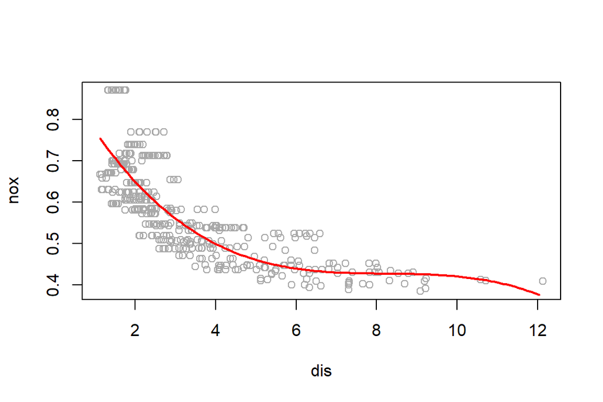

```r
dislims = range(Boston$dis)
dis.grid = seq(from = dislims[1], to = dislims[2], by = 0.1)
preds = predict(poly.fit, list(dis = dis.grid))
plot(nox ~ dis, data = Boston, col = "darkgrey")
lines(dis.grid, preds, col = "red", lwd = 2)
```

2. Plot the polynomial fits for a range of different polynomial degrees (say, from 1 to 10), and report the associated residual sum of squares.

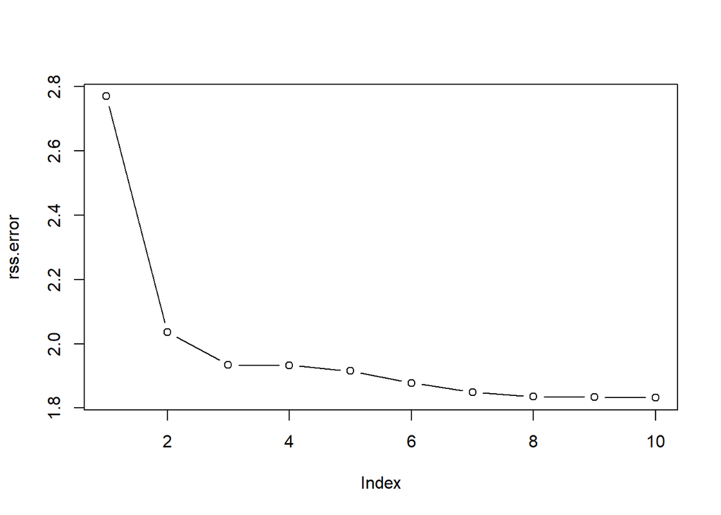

```r
rss.error = rep(0,10)
for (i in 1:10) {
  lm.fit = lm(nox~poly(dis,i), data=Boston)
  rss.error[i] = sum(lm.fit$residuals^2)
}
plot(rss.error, type="b")
```

3. Perform cross-validation or another approach to select the optimal degree for the polynomial, and explain your results.

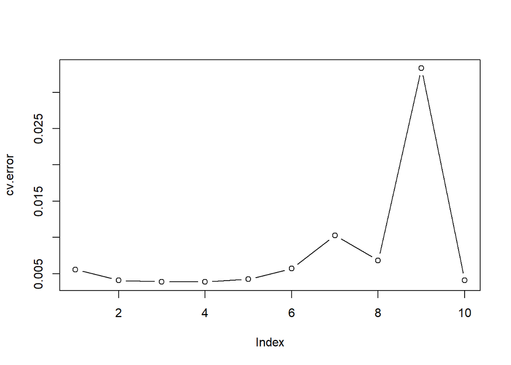

```r
require(boot)
set.seed(1)
cv.error = rep(NA,10)
for (i in 1:10) {
  glm.fit = glm(nox~poly(dis,i), data=Boston)
  cv.error[i] = cv.glm(Boston, glm.fit, K=10)$delta[1]
}
plot(cv.error, type="b")
```

- 4th degree polynomial performs best, but 2nd degree isn’t much worse
4. Use the bs() function to fit a regression spline to predict nox using dis. Report the output for the fit using four degrees of freedom. How did you choose the knots? Plot the resulting fit.

```r
rs.fit = lm(nox ~ bs(dis, knots = c(4, 7, 11)), data = Boston)
summary(rs.fit)
```

```
##
## Call:
## lm(formula = nox ~ bs(dis, knots = c(4, 7, 11)), data = Boston)
##
## Residuals:
##       Min        1Q    Median        3Q       Max
## -0.124567 -0.040355 -0.008702  0.024740  0.192920
##
## Coefficients:
##                               Estimate Std. Error t value Pr(>|t|)
## (Intercept)                    0.73926    0.01331  55.537  < 2e-16 ***
## bs(dis, knots = c(4, 7, 11))1 -0.08861    0.02504  -3.539  0.00044 ***
## bs(dis, knots = c(4, 7, 11))2 -0.31341    0.01680 -18.658  < 2e-16 ***
## bs(dis, knots = c(4, 7, 11))3 -0.26618    0.03147  -8.459 3.00e-16 ***
## bs(dis, knots = c(4, 7, 11))4 -0.39802    0.04647  -8.565  < 2e-16 ***
## bs(dis, knots = c(4, 7, 11))5 -0.25681    0.09001  -2.853  0.00451 **
## bs(dis, knots = c(4, 7, 11))6 -0.32926    0.06327  -5.204 2.85e-07 ***
## ---
## Signif. codes:  0 '***' 0.001 '**' 0.01 '*' 0.05 '.' 0.1 ' ' 1
##
## Residual standard error: 0.06185 on 499 degrees of freedom
## Multiple R-squared:  0.7185, Adjusted R-squared:  0.7151
## F-statistic: 212.3 on 6 and 499 DF,  p-value: < 2.2e-16
```

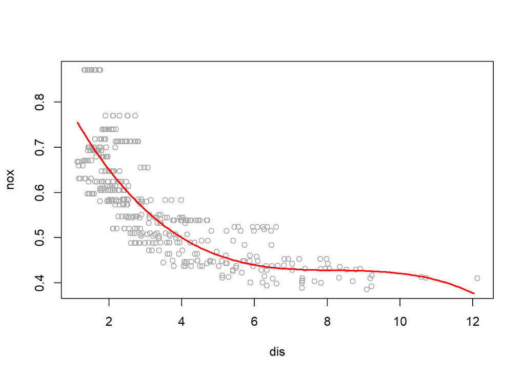

```r
pred = predict(rs.fit, list(dis = dis.grid))
plot(nox ~ dis, data = Boston, col = "darkgrey")
lines(dis.grid, preds, col = "red", lwd = 2)
```

5. Now fit a regression spline for a range of degrees of freedom, and plot the resulting fits and report the resulting RSS. Describe the results obtained.

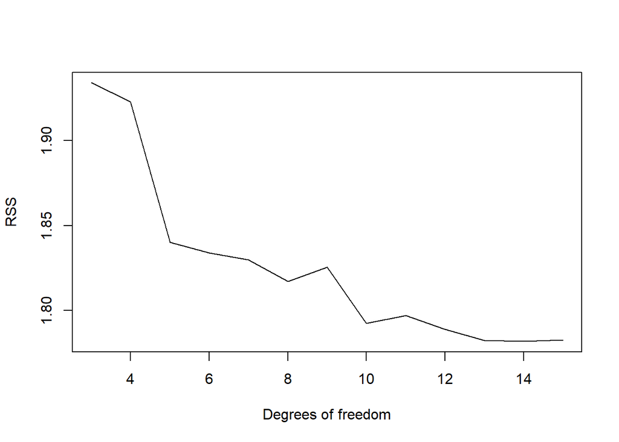

```r
rss = rep(NA, 15)
for (i in 3:15) {
    range.fit = lm(nox ~ bs(dis, df = i), data = Boston)
    rss[i] = sum(range.fit$residuals^2)
}
plot(3:15, rss[-c(1, 2)], xlab = "Degrees of freedom", ylab = "RSS", type = "l")
```

6. Perform cross-validation or another approach in order to select the best degrees of freedom for a regression spline on this data. Describe your results.

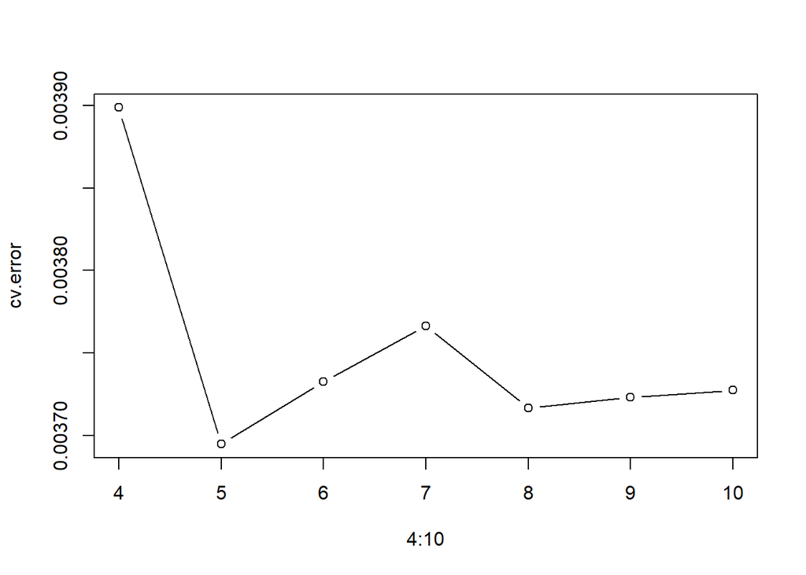

```r
cv.error = rep(0,7)
for (i in 4:10) {
  glm.fit = glm(nox~bs(dis, df=i), data=Boston)
  cv.error[i-3] = cv.glm(Boston, glm.fit, K=10)$delta[1]
}
plot(4:10, cv.error, type="b")
```

#### **10.** This question relates to the College data set.

1. Split the data into a training set and a test set. Using out-of-state tuition as the response and the other variables as the predictors, perform forward stepwise selection on the training set in order to identify a satisfactory model that uses just a subset of the predictors.

```r
require(ISLR)
require(leaps)
```

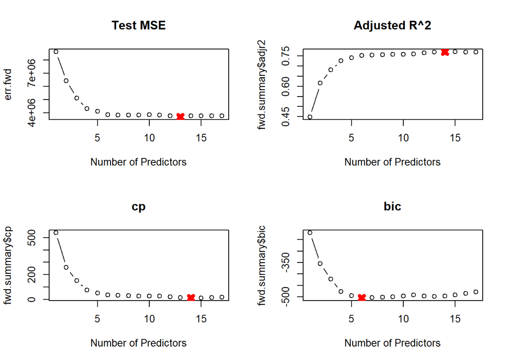

```r
data(College)
set.seed(1)

trainid = sample(1:nrow(College), nrow(College)/2)
train = College[trainid,]
test = College[-trainid,]

predict.regsubsets = function(object, newdata, id, ...){
  form = as.formula(object$call[[2]])
  mat = model.matrix(form, newdata)
  coefi = coef(object, id=id)
  xvars = names(coefi)
  mat[,xvars]%*%coefi
}

fit.fwd = regsubsets(Outstate~., data=train, nvmax=ncol(College)-1, method ="forward")
fwd.summary = summary(fit.fwd)

err.fwd = rep(NA, ncol(College)-1)
for(i in 1:(ncol(College)-1)) {
  pred.fwd = predict(fit.fwd, test, id=i)
  err.fwd[i] = mean((test$Outstate - pred.fwd)^2)
}

par(mfrow=c(2,2))
plot(err.fwd, type="b", main="Test MSE", xlab="Number of Predictors")
min.mse = which.min(err.fwd)
points(min.mse, err.fwd[min.mse], col="red", pch=4, lwd=5)
plot(fwd.summary$adjr2, type="b", main="Adjusted R^2", xlab="Number of Predictors")
max.adjr2 = which.max(fwd.summary$adjr2)
points(max.adjr2, fwd.summary$adjr2[max.adjr2], col="red", pch=4, lwd=5)
plot(fwd.summary$cp, type="b", main="cp", xlab="Number of Predictors")
min.cp = which.min(fwd.summary$cp)
points(min.cp, fwd.summary$cp[min.cp], col="red", pch=4, lwd=5)
plot(fwd.summary$bic, type="b", main="bic", xlab="Number of Predictors")
min.bic = which.min(fwd.summary$bic)
points(min.bic, fwd.summary$bic[min.bic], col="red", pch=4, lwd=5)
```

- since scores aren’t improving that much after 6 predictors we will chose the 6 predictor model

```r
err.fwd[6]
```

```
## [1] 3844857
```

2. Fit a GAM on the training data, using out-of-state tuition as the response and the features selected in the previous step as the predictors. Plot the results, and explain your findings.

```r
library(gam)
gam.fit = gam(Outstate ~ Private + s(Room.Board, 3) + s(PhD, 3) + s(perc.alumni, 3) + s(Expend, 3) + s(Grad.Rate, 3), data=train)
```

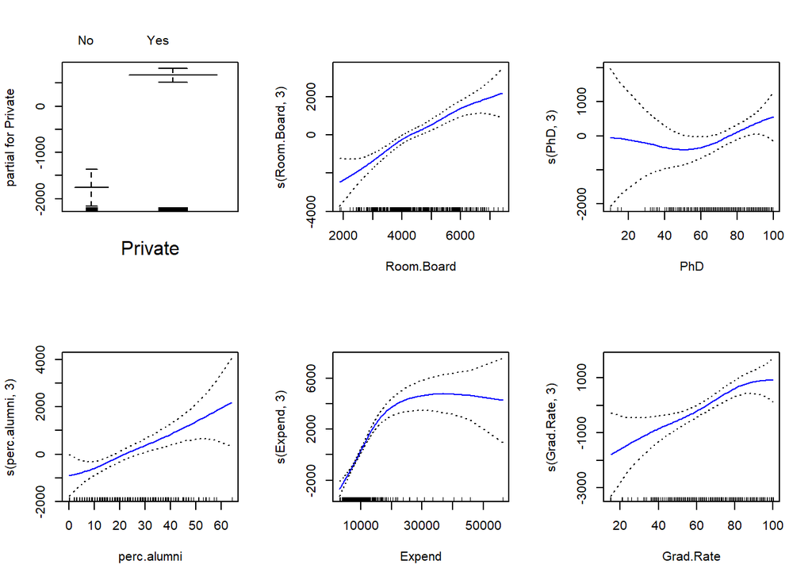

```r
par(mfrow=c(2, 3))
plot(gam.fit, se=T, col="blue")
```

3. Evaluate the model obtained on the test set, and explain the results obtained.

```r
pred = predict(gam.fit, test)
(mse.error = mean((test$Outstate - pred)^2))
```

```
## [1] 3353709
```

4. For which variables, if any, is there evidence of a non-linear relationship with the response?

```r
summary(gam.fit)
```

```
##
## Call: gam(formula = Outstate ~ Private + s(Room.Board, 3) + s(PhD,
##     3) + s(perc.alumni, 3) + s(Expend, 3) + s(Grad.Rate, 3),
##     data = train)
## Deviance Residuals:
##     Min      1Q  Median      3Q     Max
## -6963.2 -1131.7  -101.2  1322.2  7949.7
##
## (Dispersion Parameter for gaussian family taken to be 3821609)
##
##     Null Deviance: 6989966760 on 387 degrees of freedom
## Residual Deviance: 1417814885 on 370.9995 degrees of freedom
## AIC: 7000.312
##
## Number of Local Scoring Iterations: 2
##
## Anova for Parametric Effects
##                    Df     Sum Sq    Mean Sq F value    Pr(>F)
## Private             1 1767246309 1767246309 462.435 < 2.2e-16 ***
## s(Room.Board, 3)    1 1580386922 1580386922 413.540 < 2.2e-16 ***
## s(PhD, 3)           1  351828206  351828206  92.063 < 2.2e-16 ***
## s(perc.alumni, 3)   1  338018768  338018768  88.449 < 2.2e-16 ***
## s(Expend, 3)        1  498727240  498727240 130.502 < 2.2e-16 ***
## s(Grad.Rate, 3)     1   85973130   85973130  22.497 3.008e-06 ***
## Residuals         371 1417814885    3821609
## ---
## Signif. codes:  0 '***' 0.001 '**' 0.01 '*' 0.05 '.' 0.1 ' ' 1
##
## Anova for Nonparametric Effects
##                   Npar Df  Npar F    Pr(F)
## (Intercept)
## Private
## s(Room.Board, 3)        2  1.6491   0.1936
## s(PhD, 3)               2  1.2597   0.2850
## s(perc.alumni, 3)       2  0.2914   0.7474
## s(Expend, 3)            2 30.9997 3.55e-13 ***
## s(Grad.Rate, 3)         2  1.0910   0.3369
## ---
## Signif. codes:  0 '***' 0.001 '**' 0.01 '*' 0.05 '.' 0.1 ' ' 1
```

- only Expend is stat. sig. on the .05 level